```python
#@title
import os

import pandas as pd
pd.set_option('display.max_colwidth', None)
pd.set_option('display.max_columns', None)

os.chdir('/content/drive/MyDrive/Colab Files/Udacity/Udacity - Data Analyst/projects/02_WeRateDogs') # change directory
# !ls # check directory
```

# Introduction

Having done with the data wrangling process described in document two (i.e 02_wrangle_act), we discuss some key insights from the data and provide one additional visualization.

As a reminder, the dataset under focus is the WeRateDogs® [@dog_rates](https://twitter.com/dog_rates) data. WeRateDogs® is a professional dog ratings source according to their Twitter page bio.

[figure not shown]

At this point, we are at the last stage of our data analysis process. We have gathered, assessed, cleaned, combined and stored our data into a master csv data.

# Data Insights

## Top Ten Retweets

One of our interest is what are the tweets that drives engagement on the platform. A good metric for this is the retweet count. So we asked ourselves, what did WeRateDogs® [@dog_rates](https://twitter.com/dog_rates) write on their Twitter page that earned them so much engagement for that post (in terms of retweets i.e. rts).

```python
#@title
pd.read_csv('data/top_ten_rt.csv')
```

|  | text | retweet_count |
| --- | --- | --- |
| 0 | Here's a doggo realizing you can stand in a pool. 13/10 enlightened af (vid by Tina Conrad) https://t.co/7wE9LTEXC4 | 79515.0 |
| 1 | This is Stephan. He just wants to help. 13/10 such a good boy https://t.co/DkBYaCAg2d | 56625.0 |
| 2 | Here's a doggo blowing bubbles. It's downright legendary. 13/10 would watch on repeat forever (vid by Kent Duryee) https://t.co/YcXgHfp1EC | 52360.0 |
| 3 | Here's a super supportive puppo participating in the Toronto #WomensMarch today. 13/10 https://t.co/nTz3FtorBc | 48265.0 |
| 4 | This is Duddles. He did an attempt. 13/10 someone help him (vid by Georgia Felici) https://t.co/UDT7ZkcTgY | 45849.0 |
| 5 | This is Bo. He was a very good First Doggo. 14/10 would be an absolute honor to pet https://t.co/AdPKrI8BZ1 | 42228.0 |
| 6 | "Good afternoon class today we're going to learn what makes a good boy so good" 13/10 https://t.co/f1h2Fsalv9 | 37911.0 |
| 7 | Ohboyohboyohboyohboyohboyohboyohboyohboyohboyohboyohboyohboyohboyohboyohboy. 10/10 for all (by happytailsresort) https://t.co/EY8kEFuzK7 | 33421.0 |
| 8 | This is Jamesy. He gives a kiss to every other pupper he sees on his walk. 13/10 such passion, much tender https://t.co/wk7TfysWHr | 32883.0 |
| 9 | This is Kenneth. He's stuck in a bubble. 10/10 hang in there Kenneth https://t.co/uQt37xlYMJ | 31989.0 |

From the above dataframe, we see the tweets that earned WeRateDogs® [@dog_rates](https://twitter.com/dog_rates) such high engagement. Easy to spot out here is the unique ratings which WeRateDogs® [@dog_rates](https://twitter.com/dog_rates) gave the dogs i.e 13/10, 14/10 e.t.c.

## Top Ten Likes/Favourites

Another way to check for heightened engagement on Twitter is via likes/facourites. So we asked ourselves again, what did WeRateDogs® [@dog_rates](https://twitter.com/dog_rates) write on their Twitter page that earned them so much engagement for that post (in terms of likes).

```python
#@title
pd.read_csv('data/top_ten_likes.csv')
```

|  | text | favorite_count |
| --- | --- | --- |
| 0 | Here's a super supportive puppo participating in the Toronto #WomensMarch today. 13/10 https://t.co/nTz3FtorBc | 132810.0 |
| 1 | Here's a doggo realizing you can stand in a pool. 13/10 enlightened af (vid by Tina Conrad) https://t.co/7wE9LTEXC4 | 131075.0 |
| 2 | This is Duddles. He did an attempt. 13/10 someone help him (vid by Georgia Felici) https://t.co/UDT7ZkcTgY | 107956.0 |
| 3 | This is Stephan. He just wants to help. 13/10 such a good boy https://t.co/DkBYaCAg2d | 107015.0 |
| 4 | This is Jamesy. He gives a kiss to every other pupper he sees on his walk. 13/10 such passion, much tender https://t.co/wk7TfysWHr | 106827.0 |
| 5 | This is Bo. He was a very good First Doggo. 14/10 would be an absolute honor to pet https://t.co/AdPKrI8BZ1 | 95450.0 |
| 6 | This is Zoey. She really likes the planet. Would hate to see willful ignorance and the denial of fairly elemental science destroy it. 13/10 https://t.co/T1xlgaPujm | 85011.0 |
| 7 | "Good afternoon class today we're going to learn what makes a good boy so good" 13/10 https://t.co/f1h2Fsalv9 | 75639.0 |
| 8 | We only rate dogs. This is quite clearly a smol broken polar bear. We'd appreciate if you only send dogs. Thank you... 12/10 https://t.co/g2nSyGenG9 | 75193.0 |
| 9 | Here's a doggo blowing bubbles. It's downright legendary. 13/10 would watch on repeat forever (vid by Kent Duryee) https://t.co/YcXgHfp1EC | 75163.0 |

Just like earlier, looking at the above dataframe, we noticed a similar exceptionally high rating in the tweets that led to very high engagements using the like/favourite metric. We may conclude that this unique form of rating is what made WeRateDogs® [@dog_rates](https://twitter.com/dog_rates) popular.

## The most popular dog breed prediction.

One of the dataset used in our analysis is a tweet image prediciton data which was built using a neural network. We were interested in investigating what dog breed was most popular using the `p1` prediction after harmonising that `p1`, `p2` and `p3` returned that the image is that of a dog (i.e True).

```python
#@title
pd.read_csv('data/p1_pred_dog_breeds.csv')
```

|  | dog_breed | count |
| --- | --- | --- |
| 0 | golden_retriever | 117 |
| 1 | Pembroke | 77 |
| 2 | Labrador_retriever | 74 |
| 3 | Chihuahua | 50 |
| 4 | pug | 39 |
| 5 | Pomeranian | 28 |
| 6 | chow | 26 |
| 7 | toy_poodle | 26 |
| 8 | malamute | 26 |
| 9 | Samoyed | 25 |
| 10 | cocker_spaniel | 23 |
| 11 | French_bulldog | 20 |
| 12 | miniature_pinscher | 20 |
| 13 | Siberian_husky | 17 |
| 14 | German_shepherd | 17 |
| 15 | beagle | 17 |
| 16 | Staffordshire_bullterrier | 16 |
| 17 | Maltese_dog | 15 |
| 18 | Shetland_sheepdog | 15 |
| 19 | Shih-Tzu | 15 |
| 20 | Chesapeake_Bay_retriever | 15 |
| 21 | Eskimo_dog | 14 |
| 22 | Rottweiler | 14 |
| 23 | Cardigan | 14 |
| 24 | Great_Pyrenees | 13 |
| 25 | Lakeland_terrier | 13 |
| 26 | American_Staffordshire_terrier | 13 |
| 27 | Italian_greyhound | 13 |
| 28 | Border_collie | 12 |
| 29 | West_Highland_white_terrier | 11 |

The above shows us the top thirty (30) dog breed predictions while the golden retriever breed is the most popular.

## Day of the week with most tweets

Another variable of interest if finding out the day of the week with the most engagement. The dataframe below helps us to answer that question.

```python
#@title
pd.read_csv('data/tweetdays.csv', header = 0, names = ['day_of_week', 'count'])
```

|  | day_of_week | count |
| --- | --- | --- |
| 0 | Monday | 352 |
| 1 | Tuesday | 312 |
| 2 | Wednesday | 310 |
| 3 | Thursday | 295 |
| 4 | Friday | 292 |
| 5 | Sunday | 268 |
| 6 | Saturday | 268 |

## Day of the week with most engagement

Now, after combining for likes and retweets, we checked with day of the week has the most engagements.

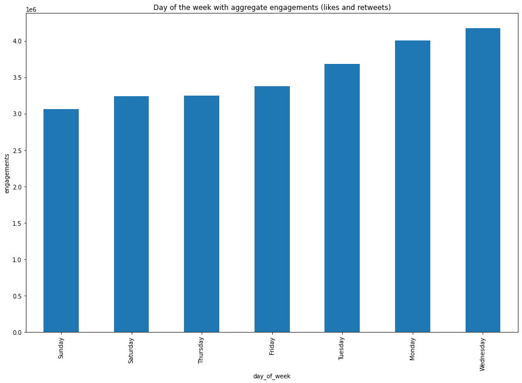

From the above image we see that Sunday has the least aggregate engagements whereas Wednesdays have the most.

# Conclusion

In this report, we have been able to explain four insights derived from the datasets which we wrangled and provided an additional visualization